# history-public-health-plague

[figure not shown]

Notre-Dame Cathedral in Paris, France. Photograph by Yoni Rodriguez, June 15, 2026.

Construction of Notre-Dame Cathedral began in *1163* and was largely completed during the medieval period. After a major fire on *April 15, 2019*, the cathedral underwent an extensive restoration and reopened in *December 2024*.

## SHM 102: Occupational Health

### Public Health History: Plague

**Lecture 03 · Fall 2026**

Yoni Rodriguez  
Engineering Technologies, Safety, and Construction  
Central Washington University  
Yoni.Rodriguez@cwu.edu

# The Black Death

[figure not shown]

Nicolas Poussin, *The Plague of Ashdod*, c. 1630.

It became one of the greatest public health disasters in recorded history.

For more than **500 years**, people could observe the disease and its devastating effects without knowing exactly what caused it or how it spread.

# A Mystery That Crossed Continents

The Black Death was one of several major plague pandemics in human history.

Its impact can be understood across both **time** and **geography**.

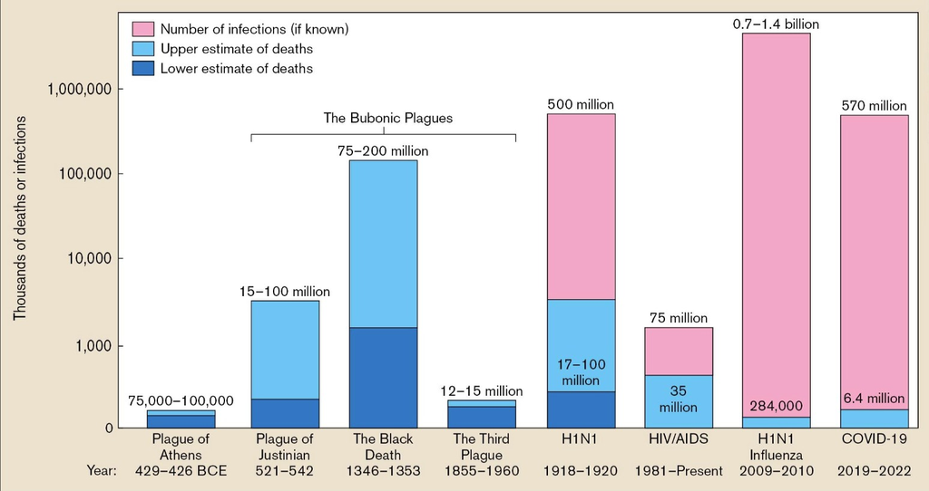

CLICK TO ENGLARGE | Comparison of major infectious disease pandemics throughout human history. Source: Slonczewski, Foster, and Zinser, *Microbiology: An Evolving Science*, 6th ed., Chapter 1, Section 1.2, Figure 1.8. © [W. W. Norton & Company](https://nerd.wwnorton.com/ebooks/epub/microbio6/EPUB/content/1.2-chapter01.xhtml).

[figure not shown]

CLICK TO ENGLARGE | Google Earth view showing geographic locations associated with the history and scientific investigation of plague across Europe, North Africa, and East Asia.

*Interactive Google Earth project created by Yoni Rodriguez.*

**Want to explore further?**  
[Explore the path of plague in Google Earth](https://earth.google.com/earth/d/1GIR5OAHve5bpCdX06T976v63LRcyeLvr?usp=sharing)

*What stands out to you?*

Consider both the **scale** of plague and the **distance** separating affected populations.

*How could the same disease appear across such distant places and populations?*

Use Poll Everywhere to share your response.

# What Could People Observe?

People could observe:

- severe illness
- fever
- painful swellings
- dark spots on the skin
- rapid death
- disease appearing in communities
- apparent spread between places and people

They could observe the **outcome**.

They could not yet observe the **cause**.

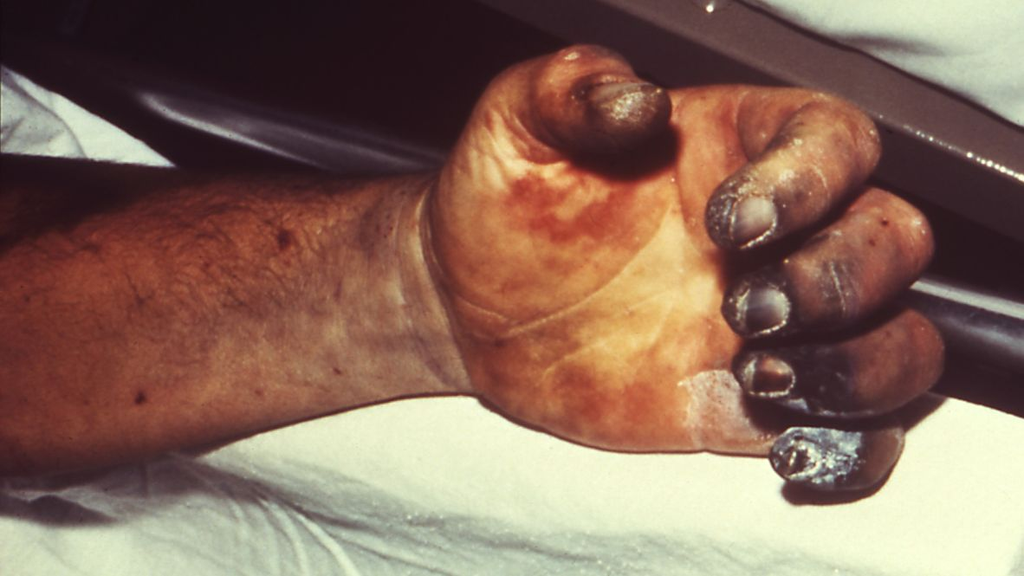

Clinical presentation of Hand necrosis caused by plague. Photograph by Dr. Jack Poland, 1975. [Centers for Disease Control and Prevention, Public Health Image Library (PHIL)](https://commons.wikimedia.org/wiki/File:Hand_necrosis_caused_by_plague.jpg)

## The Buboes

One of the most recognizable signs of plague was the appearance of painful swellings.

These swellings often appeared in the:

- groin
- armpits
- neck

They became known as **buboes**.

For centuries, people could see these swellings.

But observing a symptom did not explain what caused it.

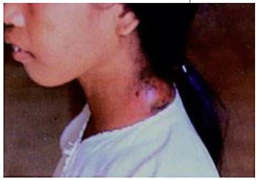

Bubo associated with bubonic plague. Source: James T. Eastman, M.D., F.C.A.P., Figure 4a, [“The Making of a Pandemic: Bubonic Plague in the 14th Century,”](https://www.jlgh.org/Past-Issues/Volume-4-Issue-1/The-Making-of-a-Pandemic.aspx) *The Journal of Lancaster General Hospital*.

# The Central Problem

People could see:

**illness**

**suffering**

**death**

**patterns of spread**

But they could not see what was causing it.

*What Would You Do Next?*

*How would you identify the cause of something you cannot see?*

There is no single correct answer.

Think about:

- what evidence you would collect
- what you would examine
- what tools you might need
- how you would test whether your explanation was correct

Use Poll Everywhere to share your response.

# Competing Explanations

People could observe disease long before they could identify its cause.

Without the ability to see microorganisms, physicians and communities developed different explanations for why people became sick.

Ideas included:

- divine punishment
- imbalance within the body
- environmental conditions
- contaminated water
- poisonous or corrupted air
- contagion between people

Some observations were meaningful.

The challenge was explaining **why** those patterns occurred.

## Imbalance Within the Body

For centuries, European medicine was strongly influenced by the **theory of the four humors**.

Health was thought to depend on maintaining a balance among:

- blood
- yellow bile
- black bile
- phlegm

Illness could therefore be interpreted as an **imbalance within the body**.

Treatments intended to restore balance included bloodletting and purging.

[figure not shown]

CLICK TO ENGLARGE | The four humors and their historical associations with elements, seasons, physical qualities, and temperaments. Chart adapted from Thomas Walkington, *Optick Glasse of Humors* (1639). Source: [U.S. National Library of Medicine](https://www.nlm.nih.gov/exhibition/shakespeare-and-the-four-humors/index.html).

## What If the Problem Was in the Air?

Another influential explanation associated disease with **miasma**, or corrupted air.

Illness was frequently observed alongside:

- overcrowding
- waste
- decomposition
- stagnant water
- poor sanitation
- unpleasant odors

These observations were not imaginary.

**The environmental conditions were real.**

What remained uncertain was the mechanism connecting those conditions to disease.

During plague outbreaks, people attempted to protect themselves from dangerous air in different ways.

The familiar image of the **plague doctor** reflects this history. Plague doctors stuffed the bird-like beaks with strong-smelling herbs and spices to protect themselves from what they believed spread disease: foul, disease-carrying air known as **miasma**, or “bad air.”

People were trying to control an exposure.

They had not yet identified the actual hazard.

[figure not shown]

Historical representation of a plague doctor wearing a beaked mask and protective clothing. Source: Rachel Hajar, [“The Air of History (Part II): Medicine in the Middle Ages,”](https://pmc.ncbi.nlm.nih.gov/articles/PMC3573364/) *Heart Views* (2012).

## Do Old Ideas Completely Disappear?

Historical explanations of disease did not simply vanish when scientific understanding changed.

People continue to search for explanations when the causes of illness are uncertain, frightening, or difficult to observe.

The explanations differ across cultures, communities, and time.

The scientific challenge remains the same:

### What evidence supports the explanation?

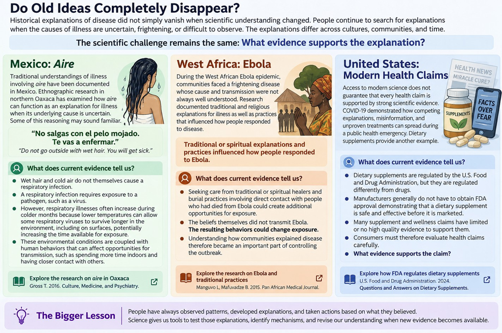

CLICK TO ENLARGE | Examples from Mexico, West Africa, and the United States illustrate how people develop explanations for illness and health, and how scientific evidence can be used to evaluate those explanations.

**Sources:** [Gross (2016), *Letting the Air Out: Aire as an Empty Signifier in Oaxacan Understandings of Illness*](https://pubmed.ncbi.nlm.nih.gov/27431429/) | [Manguvo & Mafuvadze (2015), *The Impact of Traditional and Religious Practices on the Spread of Ebola in West Africa*](https://pmc.ncbi.nlm.nih.gov/articles/PMC4709130/) | [U.S. Food and Drug Administration, *Questions and Answers on Dietary Supplements*](https://www.fda.gov/food/information-consumers-using-dietary-supplements/questions-and-answers-dietary-supplements)

## Poll Everywhere

### What explanations for illness or disease have you heard, encountered, or questioned while growing up?

Think about ideas you may have encountered through:

- family or community traditions
- school
- social media
- news or popular culture
- everyday health advice

**What was the explanation, and what evidence would you want before deciding whether it is accurate?**

Submit an example through **Poll Everywhere**.

There is no single correct answer. The goal is to identify an explanation and begin thinking about **how we could test it using evidence**.

## Seeds of Contagion

Not everyone explained disease through bodily imbalance or corrupted air.

As plague spread through medieval Europe, people increasingly recognized that the disease appeared to be **contagious**.

**NoteThe Unanswered Questions**

**What was being transmitted?**

**How was it being transmitted?**

In the sixteenth century, Italian physician **Girolamo Fracastoro “Giro” (1478–1533)** proposed that plague and other diseases could be transmitted by invisible **“seeds of contagion,”** or *seminaria*.

This was a very different hypothesis that asked whether disease was transmitted by something physical that people simply could not see.

[figure not shown]

Irwin W. Sherman’s *Twelve Diseases That Changed Our World* (2007).

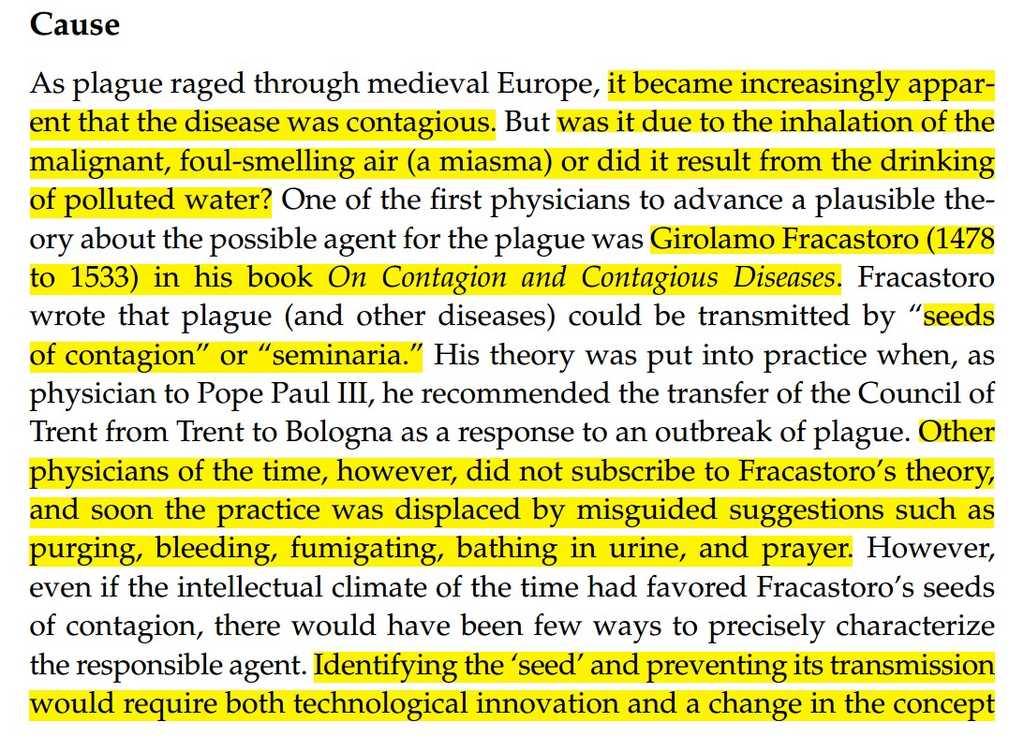

CLICK TO ENLARGE | Sherman describes competing explanations for plague and Girolamo Fracastoro’s proposal that disease could be transmitted by “seeds of contagion.” Source: Sherman (2007), “Bubonic Plague,” *Twelve Diseases That Changed Our World*.

**Source:** Sherman, I. W. (2007). “Bubonic Plague.” In *Twelve Diseases That Changed Our World* (pp. 68–82). ASM Press. https://doi.org/10.1128/9781555816346.ch5

**ImportantA Hypothesis Was Not Enough**

**Giro** had proposed something that could not yet be directly observed.

Even if **Giro** was correct, people still lacked the technology needed to identify the responsible agent.

# The Microscope

In the seventeenth century, improvements in microscopy allowed scientists to observe structures and organisms that had previously been invisible.

**Robert Hooke (1635–1703)** used a compound microscope to examine biological materials and published his observations in *Micrographia* in 1665.

Hooke observed microscopic structures and organisms, including mold, but his microscopes were not powerful enough to reveal individual bacteria.

**Antonie van Leeuwenhoek (1632–1723)** developed powerful single-lens microscopes and became the first person known to observe single-celled microorganisms, eventually including bacteria.

**ImportantSeeing Was Not the Same as Understanding**

**Humans could finally see microorganisms.**

**However, nearly two centuries passed before scientists established the connection between microorganisms and disease.**

[figure not shown]

CLICK TO ENLARGE | Mold sporangia drawn by Robert Hooke in 1665 from observations using a compound microscope. Source: Slonczewski, Foster, and Zinser, *Microbiology: An Evolving Science*, 6th ed., Figure 1.12.

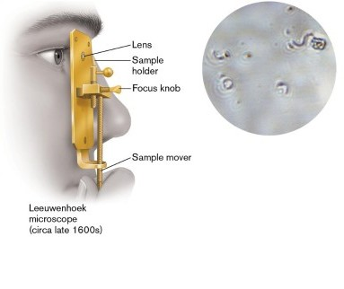

CLICK TO ENLARGE | Reconstruction of Leeuwenhoek’s single-lens microscope and a micrograph obtained using a replica. Source: Slonczewski, Foster, and Zinser, *Microbiology: An Evolving Science*, 6th ed., Figure 1.13B–C.

## Poll Everywhere

### Why do you think it took so long for humans to connect microbes with infectious disease?

There is no single answer.

Think about what scientists could **observe**, what they could **measure**, and what evidence they would need to demonstrate that a microorganism actually caused disease.

Submit your explanation through **Poll Everywhere**.

Consider the problem scientists faced:

**Seeing a microorganism does not necessarily mean that it caused the disease.**

What additional evidence would you want?

# Louis Pasteur

Remember where this lecture began?

**France.**

French chemist **Louis Pasteur (1822–1895)** investigated microorganisms while studying problems involving fermentation for the French Beer & Wine Industry.

His research demonstrated that yeast, a single-celled fungus, in the absence of oxygen produced alcohol as a terminal waste product.

In his famous **swan-neck flask experiments**, air could enter a sterilized flask of beef broth, while dust and microorganisms were trapped in the curved neck.

When a flask was tilted so that the broth contacted material trapped in the neck, microorganisms grew.

**The air was present.**

**Microbial growth was not.**

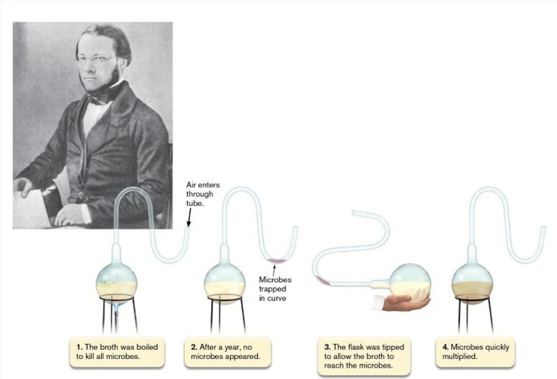

CLICK TO ENLARGE | Louis Pasteur and the swan-neck flask experiment. Source: Slonczewski, Foster, and Zinser, *Microbiology: An Evolving Science*, 6th ed., Figure 1.14.

**TipFrom Observation to Experiment**

This represented more than simply observing microorganisms.

Scientists could use **controlled experiments to test competing explanations**.

1. *Make an observation*
2. *Ask a question*
3. *Form a hypothesis*
4. *Conduct an experiment*
5. *Evaluate the evidence*

## Germ Theory

Microscopy made microorganisms visible.

Experimental science made it possible to investigate what microorganisms were doing.

During the nineteenth century, evidence from scientists including **Louis Pasteur** and **Robert Koch** helped establish the **germ theory of disease**.

The central idea was revolutionary:

### Many infectious diseases are caused by microorganisms.

Pasteur’s experiments demonstrated that microorganisms did not “simply appear” through what was considered spontaneous generation.

Koch later developed methods for studying microorganisms in isolation and establishing causal relationships between specific microorganisms and specific diseases.

**TipA New Scientific Framework**

Scientists now had:

- **a scientific framework**
- **experimental methods**
- **technologies for observing microorganisms**

Together, these developments changed the questions scientists could ask.

**Germ theory:** the theory that many infectious diseases are caused by microorganisms.

### Source

[figure not shown]

*Microbiology: An Evolving Science*, 6th ed.

The history of microscopy, Robert Hooke, Antonie van Leeuwenhoek, and Louis Pasteur:

**Slonczewski, J., Foster, J. W., & Zinser, E. R. (2024).**  
*Microbiology: An Evolving Science* (6th ed.). W. W. Norton & Company.

[Explore *Microbiology: An Evolving Science* →](https://wwnorton.com/books/9781324033523)

## Why Do Some Bacteria Cause Disease?

Our bodies contain and encounter **many microorganisms**.

Most do not cause disease.

So what makes some bacteria capable of making us sick?

### Consider *Staphylococcus aureus*

*Staphylococcus aureus* can live on the human body without necessarily causing disease.

If the **skin barrier is broken**, however, the bacterium can enter the body and cause infection.

Under some circumstances, infection may be relatively minor.

Under other circumstances, *S. aureus* can cause **serious, life-threatening infections** and is an important cause of infections in hospitals.

### So what changed?

The bacterium matters.

But so do the **conditions that allow it to enter, survive, and cause disease**.

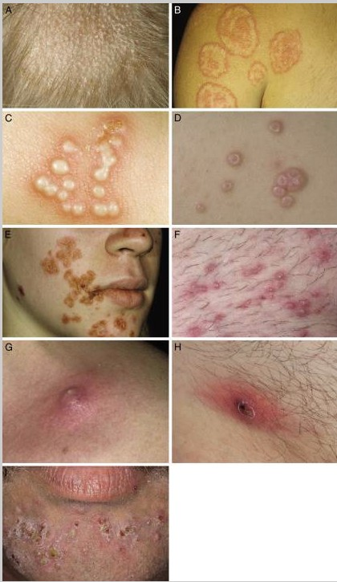

A. Tinea capitis. B. Tinea corporis. C. Herpes simplex. D. Molluscum contagiosum. E. Impetigo. F. Folliculitis. G. Furuncle/carbuncle. H and I. Methicillin-resistant *Staphylococcus aureus*. [Source](https://pmc.ncbi.nlm.nih.gov/articles/PMC2902037/)

## Pathogenicity and Virulence

**Pathogenicity**

The ability of a microorganism to cause disease.

**Virulence**

The degree of pathogenicity or the capacity of a pathogen to cause disease.

Some pathogens possess **virulence factors** that increase their ability to infect a host, overcome host defenses, or cause damage.

These can include structures or characteristics that help a microorganism:

- **move** through its environment, such as flagella
- **attach** to host cells or tissues using surface proteins
- **invade** cells or tissues
- **avoid or resist** host immune defenses
- **produce toxins** or other substances that damage the host

**ImportantThe Microorganism Is Only Part of the Story**

The characteristics of the microorganism matter, but whether disease develops can also depend on:

- the route of exposure
- the **infectious dose**
- the environment
- the susceptibility of the host

### Infectious Dose

**Infectious dose** is the amount of an infectious agent needed to establish an infection.

The infectious dose can vary dramatically between microorganisms.

For example, *Vibrio cholerae* may require a relatively large number of bacterial cells to establish infection because many cells are destroyed by stomach acid.

The number required can decrease substantially when stomach acidity is reduced.

### Why does that matter?

Exposure is not simply:

**Were you exposed?**

We also need to ask:

**How much of the agent reached the susceptible host?**

So identifying a microorganism is not the end of the investigation.

We still need to understand **what it can do, how much exposure occurs, how it enters the host, and who is susceptible**.

# Case Study: Hong Kong, 1894

It is **1894**.

A major outbreak of plague has reached **Hong Kong**.

People are becoming severely ill and dying.

Scientists now have tools their medieval predecessors did not:

- germ theory
- improved microscopes
- staining techniques
- experimental methods

You are part of a scientific team sent to investigate the outbreak.

Your task is not simply to describe what is happening.

**NoteYour Investigation**

**Your task is to identify the cause.**

What evidence would you collect?

Where would you look?

What would you examine?

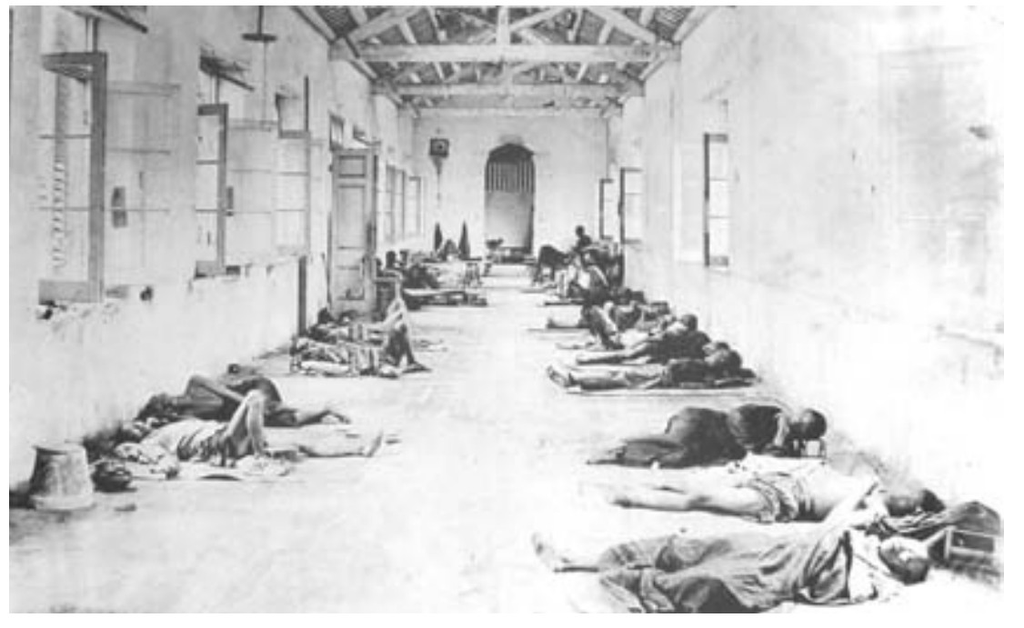

CLICK TO ENLARGE | Men’s ward at the Kennedy Town Glassworks emergency plague hospital during the 1894 Hong Kong plague epidemic. Source: Echenberg (2007), “An Unexampled Calamity: Hong Kong, 1894,” *Plague Ports: The Global Urban Impact of Bubonic Plague, 1894–1901*.

**Source:** Echenberg, M. (2007). “An Unexampled Calamity: Hong Kong, 1894.” In *Plague Ports: The Global Urban Impact of Bubonic Plague, 1894–1901* (pp. 16–46). NYU Press. [Access through JSTOR →](http://www.jstor.org.offcampus.lib.washington.edu/stable/j.ctt9qgb84.7)

## Use What You Already Know

Remember the **One Health systems model** from our public health history?

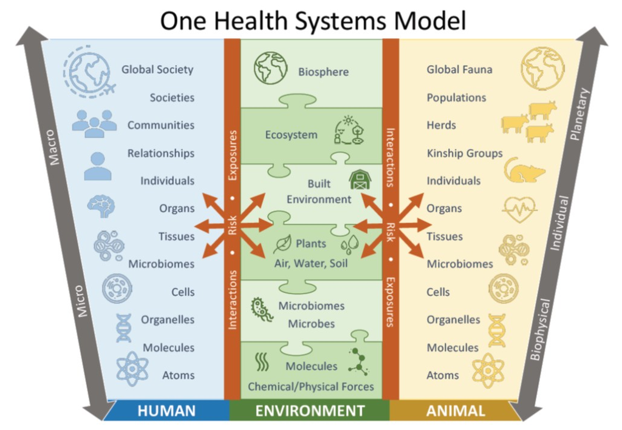

One Health systems model connecting human, animal, and environmental health.

**NoteInvestigate the System**

Working with the people around you, consider the outbreak through three parts of the system:

**Humans**

- Who is becoming sick?
- What symptoms are occurring?
- What do affected people have in common?

**Animals**

- What animals are present?
- Are any animals becoming sick or dying?
- How might people interact with them?

**Environment**

- Where are cases occurring?
- What conditions might allow the disease to move?
- What work or daily activities could create opportunities for exposure?

## Poll Everywhere

### Where would you investigate first?

If you were investigating this outbreak in **1894**, where would you collect evidence first, and why?

Think about the **human, animal, and environmental** parts of the system.

# Meet Alexandre Yersin

**Alexandre Yersin**, a bacteriologist associated with the Pasteur Institute, traveled to Hong Kong to investigate the epidemic.

Yersin had essentially been given the problem you just worked through.

His task was to identify the organism responsible for plague.

### But first he needed a specimen.

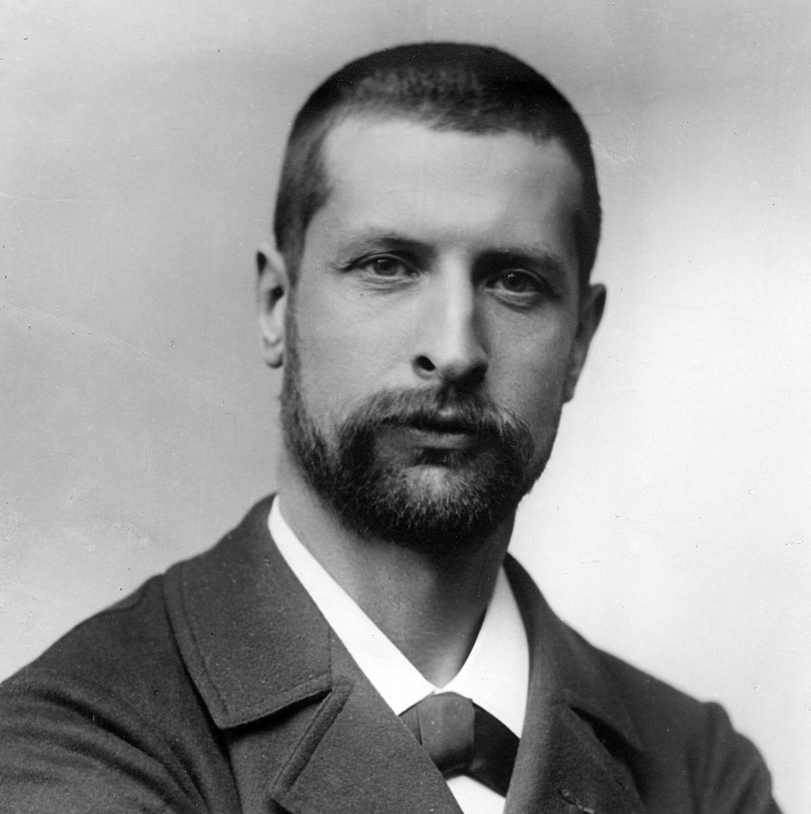

Alexandre Yersin (1863–1943)

## The Bubo Becomes Evidence

Yersin obtained access to the body of a person who had recently died from plague.

Using a sterile needle, he collected fluid from a **bubo**.

Think about the progression.

A swelling that physicians had observed for centuries was no longer only a symptom.

**TipFrom Symptom to Specimen**

**The bubo became a source of biological evidence.**

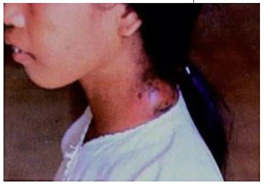

Bubo associated with bubonic plague. Source: James T. Eastman, M.D., F.C.A.P., Figure 4a, [“The Making of a Pandemic: Bubonic Plague in the 14th Century,”](https://www.jlgh.org/Past-Issues/Volume-4-Issue-1/The-Making-of-a-Pandemic.aspx) *The Journal of Lancaster General Hospital*.

## Following the Evidence

Yersin examined the bubo fluid under a microscope.

He found it filled with bacteria.

Now there was a candidate organism.

But seeing bacteria in a sick person did not automatically prove that the bacteria caused plague.

Yersin used material from the bubo to inoculate guinea pigs.

The guinea pigs died.

When he examined them, he found the same bacteria.

The bacterium responsible for plague would eventually be named:

### *Yersinia pestis*

in recognition of Alexandre Yersin.

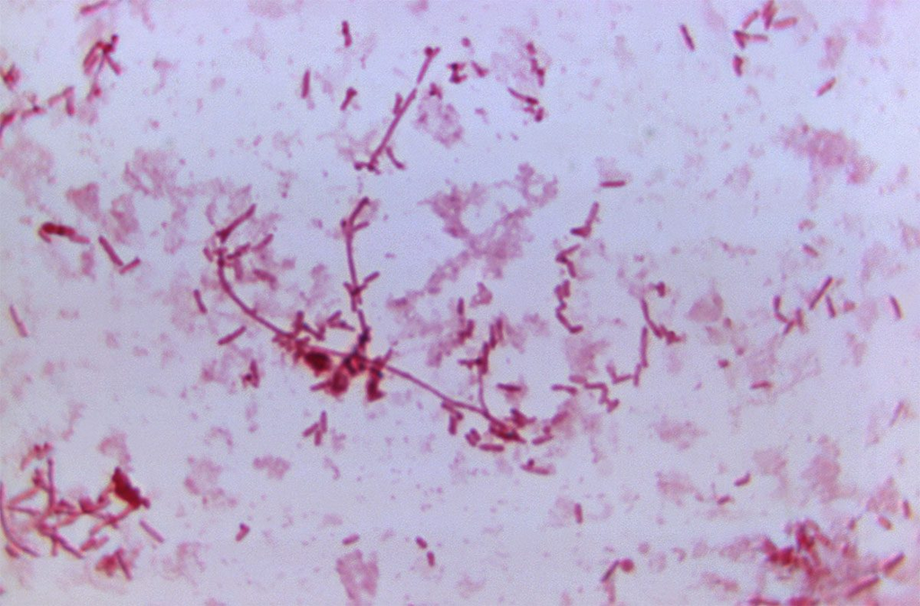

*Yersinia pestis*, the bacterium that causes plague. Image: CDC / Dr. D. S. Martin. [Source](https://globalbiodefense.com/2025/07/22/decoding-plagues-evolution-a-tipping-point-in-yersinia-pestis-fitness-and-adaptation/)

## A One Health Clue

Yersin noticed something else.

There were large numbers of dead rats in the streets, hospital corridors, and around the morgue.

He examined some of the rats.

### He found the same bacteria.

**NoteReturn to the One Health Model**

You now have evidence connecting the same organism with:

**Humans**

and

**Rats**

What does this new evidence add to your One Health systems model?

What relationship would you investigate next?

[figure not shown]

Urban rats feeding on discarded food in New York City. Photograph by Charlie Hamilton James. [Source: National Geographic](https://www.nationalgeographic.com/magazine/article/rats-are-an-inescapable-part-of-city-life)

## Poll Everywhere

### What would you investigate next?

You have found the **same bacterium in humans and rats**.

What would you investigate next to determine **how the bacterium reaches humans**?

Think about:

- human activities
- animal contact
- the environment
- possible intermediaries
- patterns that could distinguish one explanation from another

# Back to 1894

### What Had Yersin Solved?

Yersin had answered an enormous question.

### What causes plague?

**A bacterium: *Yersinia pestis*.**

**NoteOne Question Remained**

But another question remained unanswered.

**How was the bacterium moving between rats and humans?**

Knowing the **hazard** did not automatically reveal the **exposure pathway**.

We know the agent.

We know humans and rats can be infected.

But we still do not know the exposure pathway.

**NoteThe Next Investigation**

If rats and humans can carry the same organism, how would you determine **how the organism moves from rats to humans?**

Yersin had connected plague with rats.

Another investigator would take the next major step.

# Paul Louis Simond

French army physician **Paul Louis Simond** traveled to Vietnam and India to follow up on Yersin’s observations.

He noticed an important occupational health pattern.

Twenty laborers in a wool factory had been cleaning dead rats from the floor.

**Those 20 workers died of plague.**

Other factory workers who had **no contact with the rats** did not become ill.

That observation suggested an exposure relationship.

### Look at the Task

The workers shared a workplace.

But they did not share the same **task** or **opportunity for exposure**.

**What was different about the work performed by the workers who became ill?**

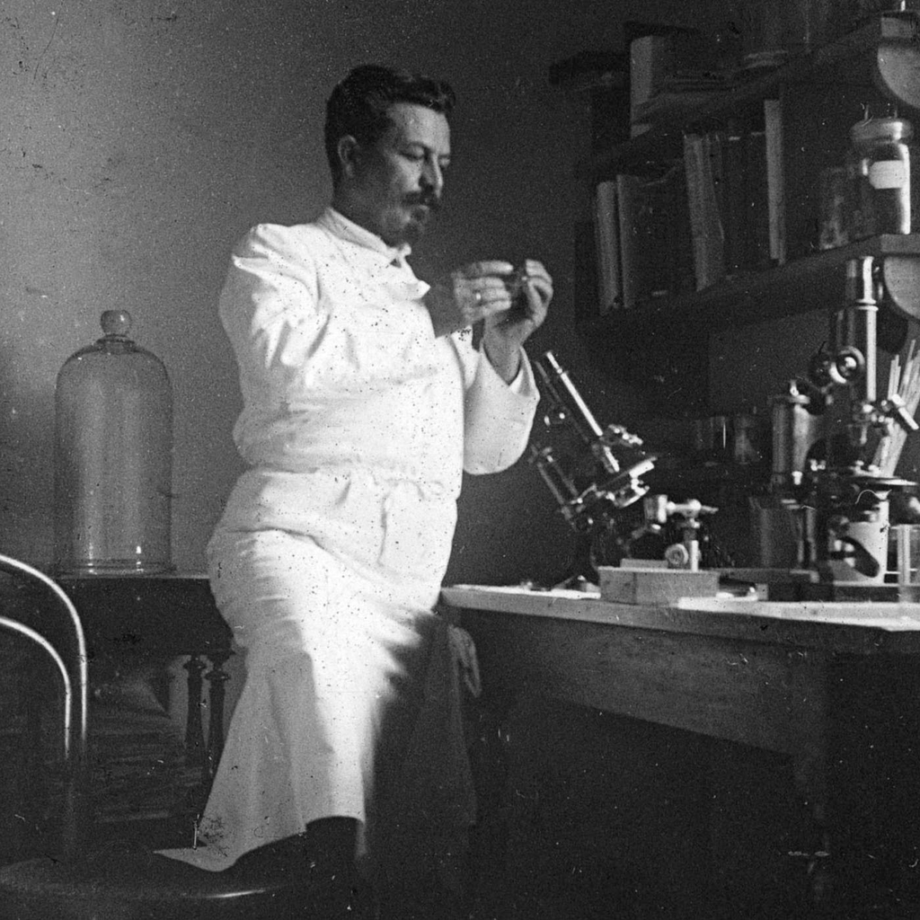

Paul Louis Simond investigating plague. Source: [Institut Pasteur](https://www.pasteur.fr/en/about-us/paul-louis-simond-world-traveler-working-multiple-diseases).

## Poll Everywhere

### What additional information would you want?

The important question is **not** simply:

**What was their job title?**

Think like an exposure scientist.

What would you want to know about the workers’ **tasks, animal contact, and work environment** before deciding how exposure might be occurring?

Some workers were cleaning floors containing dead rats.

Their work created an opportunity for exposure.

## Another Observation

Simond noticed something about the rats.

Healthy rats groomed themselves and tended to have relatively few fleas.

Sick rats could no longer groom effectively.

They carried many fleas.

Then the rats died.

### What happened to the fleas?

## A Hypothesis

Simond proposed that an intermediary might connect infected rats with humans.

Perhaps the rat itself was not directly transmitting the disease.

# Testing the Hypothesis

Simond designed an experiment.

He placed a **plague-infected rat at the bottom of a jar**.

Above it, he suspended a **healthy rat in a wire mesh cage**.

The wire mesh prevented the rats from directly touching.

But fleas could move from the sick rat to the healthy rat.

### The healthy rat developed plague.

[figure not shown]

BBC reconstruction of Paul Louis Simond’s experiment investigating flea-mediated plague transmission. [Source](https://www.youtube.com/watch?v=lDwiLdEKyu0)

## The Control

Simond also tested what happened when fleas were absent.

Without fleas, healthy rats exposed to the experimental conditions did not develop plague.

When fleas were introduced:

### plague appeared.

The transmission pathway was becoming clear.

# The Transmission Pathway

## Rodent → Flea → Human

Plague can move between rodents and humans through **fleas**.

A flea feeds on a rodent infected with *Yersinia pestis* and acquires the bacterium.

When an infected rodent becomes sick or dies, fleas may leave the animal and seek another blood meal.

If an infected flea bites a human, *Yersinia pestis* can enter the new host.

### Rodent → Flea → Human

This was the transmission pathway Simond had been investigating.

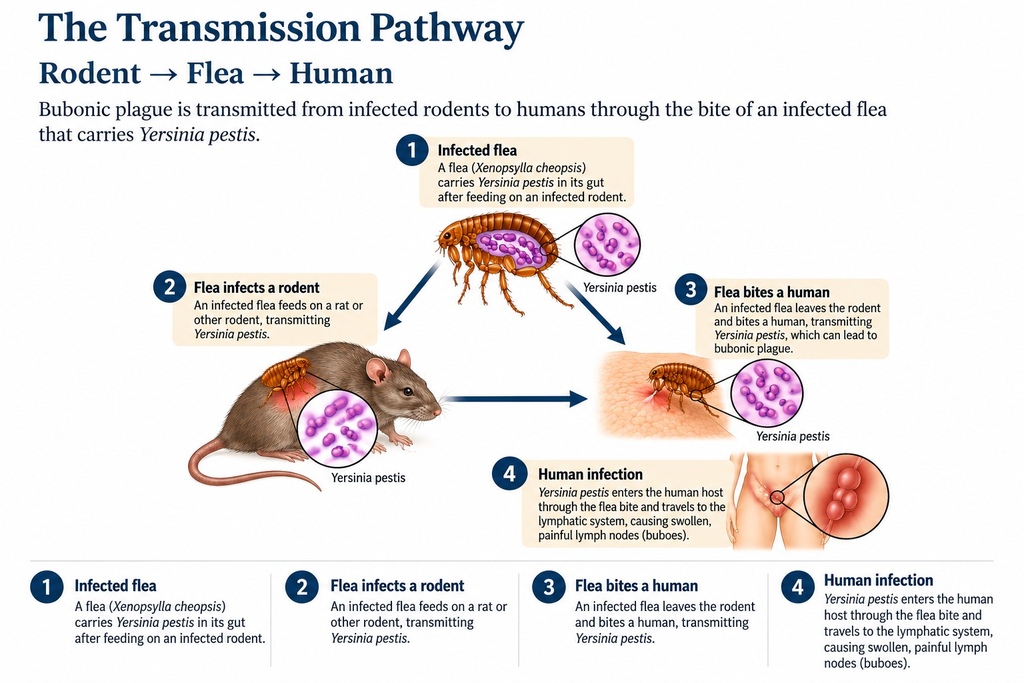

Bubonic plague transmission pathway showing the relationship between *Yersinia pestis*, fleas, rodents, and human infection.

# Agent, Reservoir, Vector, Susceptible Host

We can now give names to the major parts of an infectious disease transmission system.

## Agent

A microorganism (bacterium, virus, fungus, or other infectious material) that causes disease.

## Reservoir

An organism that maintains a virus or bacterial pathogen in an area by serving as a host.

## Vector

An organism (e.g., insect) that can carry infectious agents from one animal to another.

## Susceptible Host

A person or animal that can become infected by an infectious agent due to lack of immunity.

# Understanding the Disease

Now that we know the agent, we can better understand what happens after infection.

*Yersinia pestis* can produce different forms of disease depending on **where the infection develops in the body**.

### Bubonic Plague

Bacteria reach the **lymphatic system** and multiply in regional lymph nodes, producing swollen lymph nodes called **buboes**.

### Septicemic Plague

Bacteria enter the **bloodstream**, producing a severe systemic infection.

### Pneumonic Plague

Bacteria infect the **lungs**.

Respiratory droplets from a person or animal with pneumonic plague can transmit *Yersinia pestis* to another person.

### Same Agent, Different Forms of Disease

The agent remains the same:

*Yersinia pestis*

What changes is **where the infection develops in the body**.

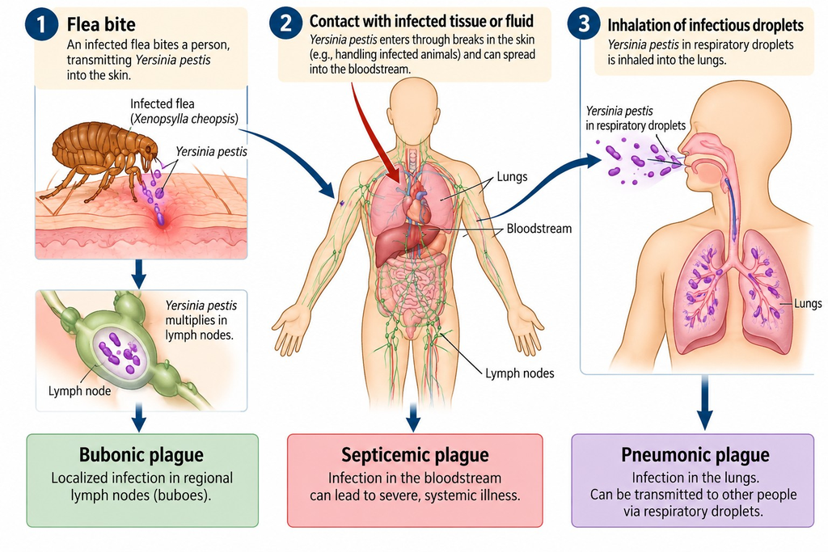

Routes of exposure and forms of disease caused by *Yersinia pestis*.

# From Microbiology to Occupational Health

Now consider plague as an occupational health problem.

### Who might encounter this exposure pathway because of their work?

Possible occupational groups include:

- ranchers
- livestock workers
- veterinarians
- veterinary technicians
- animal control workers
- wildlife biologists
- agricultural workers
- pest control workers

The occupational hazard is not determined by the job title alone.

It depends on the **task and opportunity for exposure**.

## Think Like an Exposure Scientist

For any biological hazard, ask:

- What is the agent?
- Where is the reservoir?
- How does it leave the reservoir?
- How does it move through the environment?
- How does it reach the worker?
- What route allows it to enter the body?

# Plague in the United States

Plague still occurs naturally in parts of the **western United States**.

*Yersinia pestis* circulates among wild rodents and their fleas.

Humans and domestic animals can be exposed when infected fleas seek another host.

This means plague remains relevant to:

- wildlife work
- veterinary work
- outdoor work
- animal handling
- public health surveillance

Although human plague is uncommon, recognizing the **agent, reservoir, vector, and susceptible host** helps us understand where exposure can occur and how it can be prevented.

[figure not shown]

Plague ecology in the United States, showing transmission among wild rodents and fleas and opportunities for exposure among humans and domestic animals. [Source](https://www.cdc.gov/plague/causes/index.html)

# From Hong Kong to Central Washington

The investigation that began in Hong Kong helped reveal how *Yersinia pestis* moves through an environment and reaches humans.

More than a century later, plague remains present in the United States.

Human cases have occurred primarily in the **western United States**.

The geographic pattern reminds us that infectious disease transmission depends on more than the presence of an agent.

It also depends on:

- animal reservoirs
- vectors
- environmental conditions
- opportunities for human exposure

### What biological hazards follow similar pathways in Central Washington?

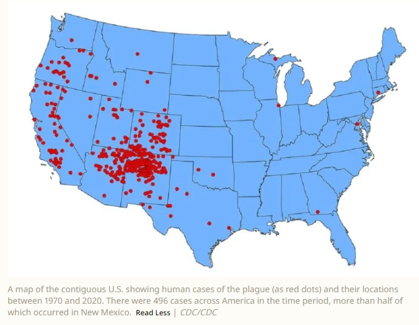

Reported human plague cases in the contiguous United States, 1970–2020. Red dots indicate locations of reported cases. CDC data and map. [Source](https://www.newsweek.com/plague-map-us-cases-since-1970-new-mexico-1878428)

# Key Takeaway

The disease existed before we understood it.

The exposure pathway existed before we understood it.

The hazard did not suddenly appear when scientists identified it.

### Our ability to observe, measure, and explain it changed.

Plague provides a historical example of how **observation, technology, experimentation, microbiology, and exposure science** can help us understand a biological hazard.

In occupational health, identifying the hazard is only the beginning.

We also need to understand:

- where it comes from
- how it moves
- who encounters it
- how exposure occurs
- what happens after exposure
- where we can intervene

# Key Terms

| Term | Definition |
| --- | --- |
| **Germ theory** | The scientific concept that microorganisms can cause disease. |
| **Pathogen** | A biological agent capable of causing disease. |
| **Pathogenicity** | The ability of a microorganism to cause disease. |
| **Virulence** | The degree of pathogenicity or the capacity of a pathogen to cause disease. |
| **Virulence factor** | A structure or characteristic that increases a microorganism’s ability to infect a host, overcome host defenses, or cause damage. |
| **Infectious dose** | The amount of an infectious agent needed to establish an infection. |
| **Agent** | A microorganism or other infectious material that causes disease. |
| **Reservoir** | An organism that maintains a virus or bacterial pathogen in an area by serving as a host. |
| **Vector** | An organism that can carry infectious agents from one animal to another. |
| **Susceptible host** | A person or animal that can become infected by an infectious agent due to lack of immunity. |
| **Transmission route** | The way an infectious agent moves from its source or reservoir to a susceptible host. |
| **Vector-borne transmission** | Transmission of an infectious agent through a living vector. |
| *Yersinia pestis* | The bacterium that causes plague. |

## Make your flashcards

### Copy → Paste → Study

Copy the terms below to make your own **Anki or Quizlet** flashcards.

**Anki:** Save as a `.txt` file → Import → Select **Semicolon** as the field separator.

```
Germ theory;The scientific concept that microorganisms can cause disease.
Pathogen;A biological agent capable of causing disease.
Pathogenicity;The ability of a microorganism to cause disease.
Virulence;The degree of pathogenicity or the capacity of a pathogen to cause disease.
Virulence factor;A structure or characteristic that increases a microorganism's ability to infect a host, overcome host defenses, or cause damage.
Infectious dose;The amount of an infectious agent needed to establish an infection.
Agent;A microorganism or other infectious material that causes disease.
Reservoir;An organism that maintains a virus or bacterial pathogen in an area by serving as a host.
Vector;An organism that can carry infectious agents from one animal to another.
Susceptible host;A person or animal that can become infected by an infectious agent due to lack of immunity.
Transmission route;The way an infectious agent moves from its source or reservoir to a susceptible host.
Vector-borne transmission;Transmission of an infectious agent through a living vector.
Yersinia pestis;The bacterium that causes plague.
```

### Copyright & Use

**SHM 102: Occupational Health**  
© 2026 Yoni Rodriguez

Except where otherwise noted, original course materials are licensed under the Creative Commons Attribution-NonCommercial 4.0 International License (CC BY-NC 4.0).

Third-party materials remain subject to their respective copyright and licensing terms.